# Ejercicio #1: Pronóstico PIB

Juan Andrés Páez

20-10-2025

## **Objetivo**

El análisis de series de tiempo constituye una herramienta fundamental en la economía, ya que permite estudiar el comportamiento de variables macroeconómicas a lo largo del tiempo y realizar proyecciones basadas en sus patrones históricos. En este ejercicio se buscó aplicar un modelo ARIMA (Autoregressive Integrated Moving Average) al Producto Interno Bruto (PIB) de Colombia, utilizando datos anuales desde 1960 hasta 2024 a precios constantes en miles de millones de USD con base en el 2015.

La metodología empleada se basó en el enfoque de Box y Jenkins, el cual propone un proceso sistemático que incluye la identificación, estimación, diagnóstico y validación del modelo. Este procedimiento permite determinar la estructura estadística que mejor se ajusta a la dinámica temporal de la serie, ofreciendo una visión inicial sobre su comportamiento y posibles tendencias.

En particular, este ejercicio buscó resaltar que, aunque estos modelos resultan útiles y relativamente sencillos de implementar, su naturaleza univariada impide considerar otros factores macroeconómicos que influyen en el PIB

## **Datos**

| fecha | USD (MM) |
| --- | --- |
| 1960 | 30.60735 |
| 1961 | 32.16503 |
| 1962 | 33.90576 |
| 1963 | 35.02015 |
| 1964 | 37.17982 |
| 1965 | 38.51829 |
| 1966 | 40.53540 |
| 1967 | 42.21148 |
| 1968 | 44.71594 |
| 1969 | 47.44473 |

[output cut: 55 more lines]

## **Metodología Box and Jenkins**

### Identificación

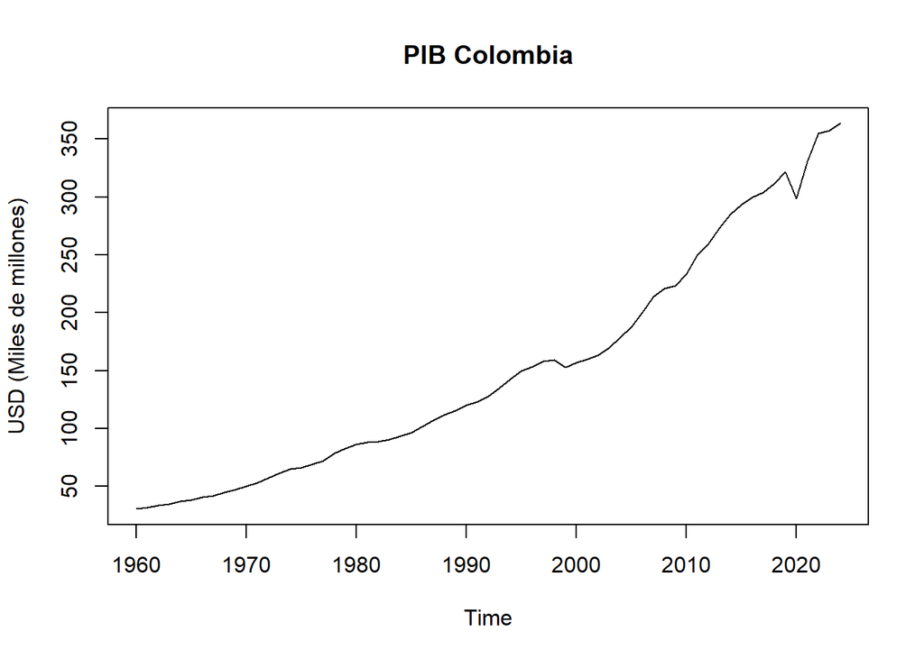

```r
plot(PIB, main="PIB Colombia", xlab="Time", ylab="USD (Miles de millones)")
```

Se observa un crecimiento general de PIB desde el año 1960 con leves caídas en su tendencia. En 1999 se presenta una caída de 4,46 mil millones de dólares, sin embargo, su tendecia continuó creciendo llegando a 321,40 mil millones de dólares en el 2019, para posteriormente caer a 298,3 mil millones de dólares en el 2020 como producto de la pandemia por el Covid-19. En el año 2024 el PIB alcanzó los 363,5 mil millones de dólares.

Aplicamos logaritmo al PIB para estabilizar su varianza.

```r
PIB = log(PIB)
```

### Gráficas autocorrelación y autocorrelación parcial

Observamos las gráficas de autocorrelación y autocorrelación parcial para analizar el comportamiento de los rezagos.

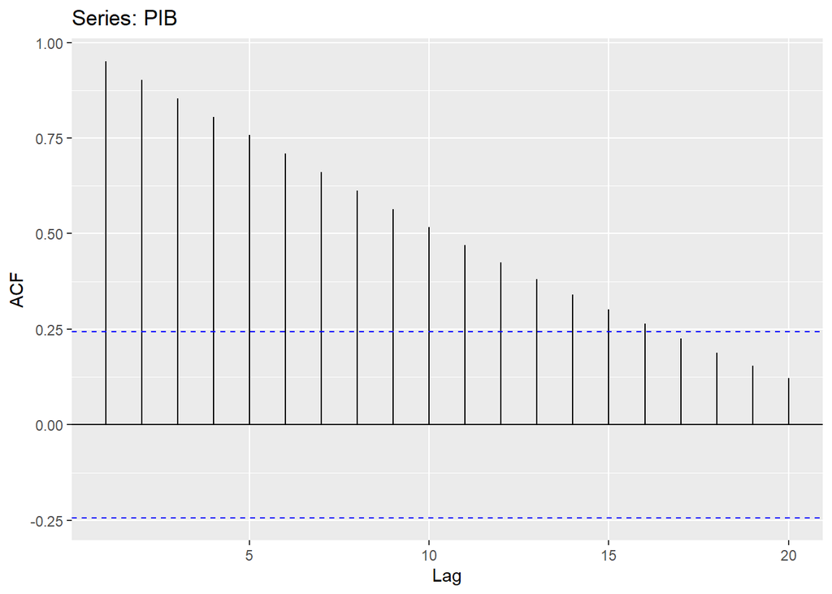

```r
ggAcf(PIB, lag.max = 20)
```

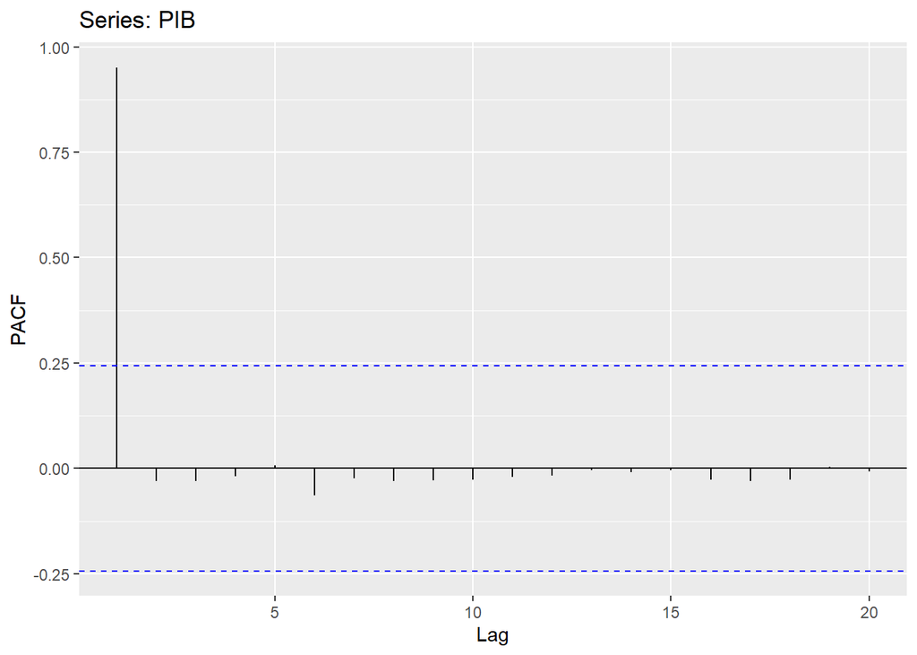

```r
ggPacf(PIB, lag.max = 20)
```

Observamos en la gráfica de autocorrelación que a partir del primer rezago existe una caída suave, lo que indica que no existe estacionariedad, siendo esta fundamental para nuestros modelos predictivos, sin embargo realizamos las pruebas de Dickey - Fuller, Phillips- Perron y Kwiatkowski-Phillips-Schmidt-Shin para confirmar la ausencia de estacionariedad.

```r
adf.test(PIB)
```

```
##
##  Augmented Dickey-Fuller Test
##
## data:  PIB
## Dickey-Fuller = -2.2745, Lag order = 3, p-value = 0.4637
## alternative hypothesis: stationary
```

```r
pp.test(PIB)
```

```
##
##  Phillips-Perron Unit Root Test
##
## data:  PIB
## Dickey-Fuller Z(alpha) = -5.207, Truncation lag parameter = 3, p-value
## = 0.8103
## alternative hypothesis: stationary
```

```r
kpss.test(PIB)
```

```
##
##  KPSS Test for Level Stationarity
##
## data:  PIB
## KPSS Level = 1.7005, Truncation lag parameter = 3, p-value = 0.01
```

Se observa que en las pruebas de Dickey-Fuller y Pillihps-Perron el p-value es mayor a 5%, es decir no hay evidencia suficiente para rechazar la hipótesis nula, por lo cual no hay estacionariedad. Por otro lado, la prueba Kwiatkowski-Phillips- Schmidt-Shin, muestra un p-value menor al 5% lo que nos indica que se rechaza la hipótesis nula a favor de la alterna, por lo tanto, no hay existencia de estacionariedad.

### Transformación

Para volver nuestra serie estacionaria es necesario aplicar diferencias, por lo cual usamos la función “ndiffs” que nos permite saber cuántas diferencias son necesarias para que nuestra serie sea estacionaria.

```r
ndiffs(PIB)
```

```
## [1] 1
```

```r
PIB_est = diff(PIB, differences = 1)
```

Aplicamos el número de diferencias indicadas y graficamos nuestra serie (ahora estacionaria).

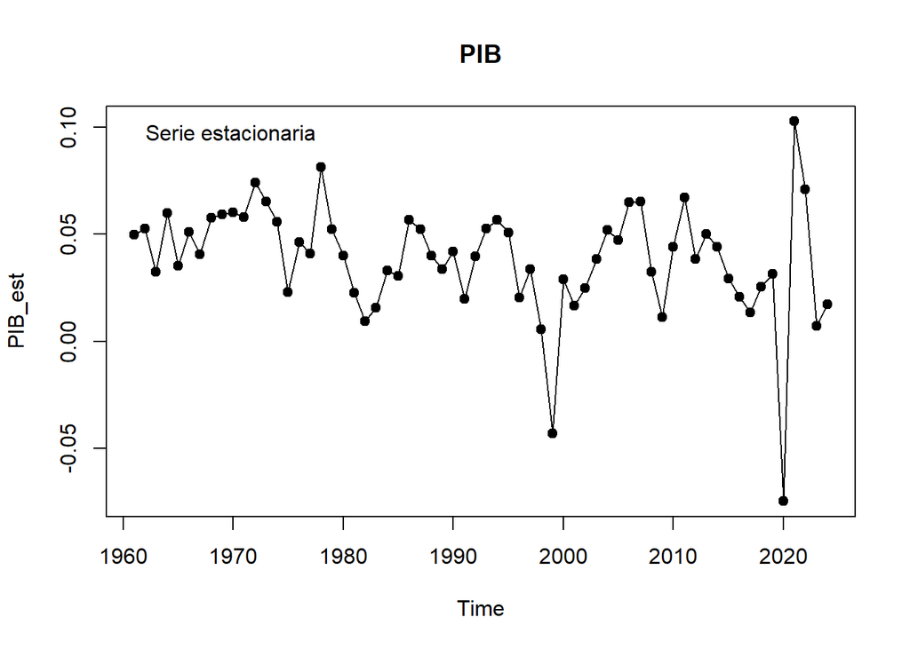

```r
plot(PIB_est, type="o", pch=21, bg="black", lty="solid", col="black", main= "PIB", xlab="Time")
legend("topleft", legend= "Serie estacionaria", bty="n")
```

Volvemos a realizar nuestras pruebas de estacionariedad.

```r
adf.test(PIB_est)
```

```
##
##  Augmented Dickey-Fuller Test
##
## data:  PIB_est
## Dickey-Fuller = -3.7219, Lag order = 3, p-value = 0.03008
## alternative hypothesis: stationary
```

```r
pp.test(PIB_est)
```

```
##
##  Phillips-Perron Unit Root Test
##
## data:  PIB_est
## Dickey-Fuller Z(alpha) = -56.665, Truncation lag parameter = 3, p-value
## = 0.01
## alternative hypothesis: stationary
```

```r
kpss.test(PIB_est)
```

```
##
##  KPSS Test for Level Stationarity
##
## data:  PIB_est
## KPSS Level = 0.40302, Truncation lag parameter = 3, p-value = 0.07585
```

Observamos que en las pruebas Dickey - Fuller y Phillips - Perron el p-value es menor al 5%, esto quiere decir que se rechaza la hipótesis nula a favor de la alterna, es decir, nuestra serie es estacionaria. Por otro lado, el test Kwiatkowski-Phillips-Schmidt-Shin nos arroja un p-value mayor al 5% por lo cual no hay evidencia suficiente para rechazar la hipótesis nula, es decir, existe estacionariedad.

### Gráficas autocorrelación y autocorrelación parcial

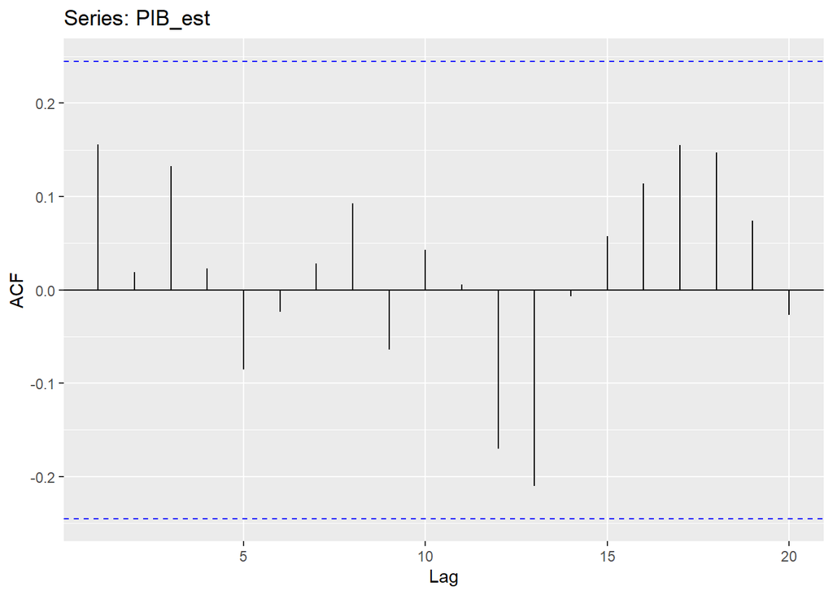

```r
ggAcf(PIB_est, lag.max = 20)
```

Se observa en nuestra gráfica de autocorrelación que ningún rezago es significativo, esto sugiere la ausencia del componente MA.

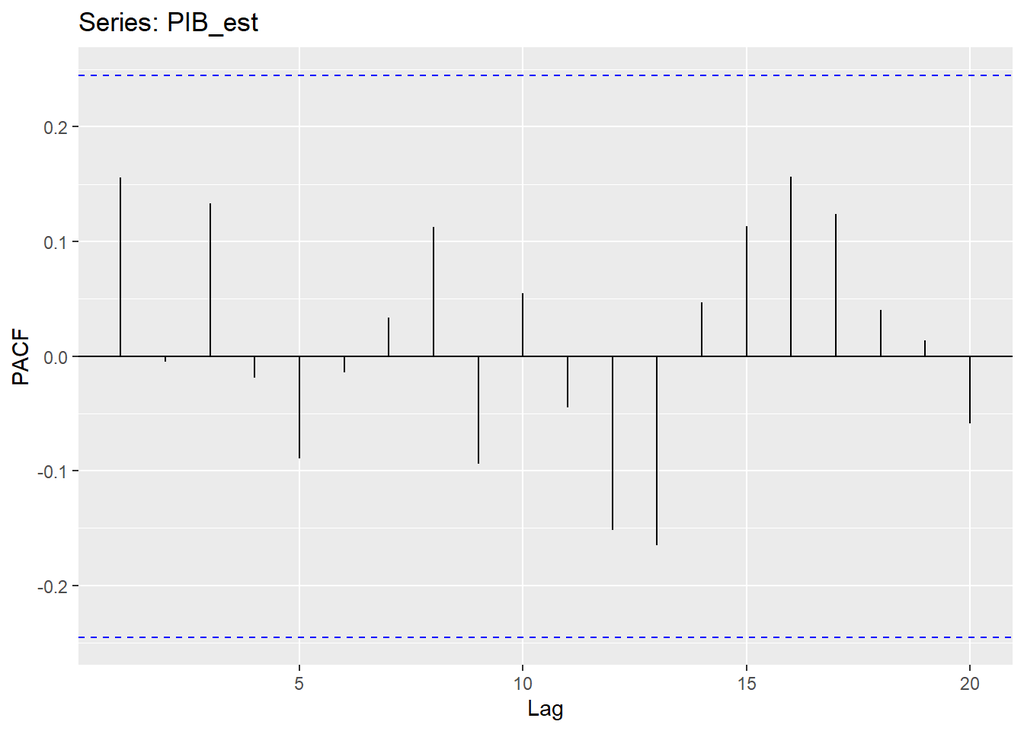

```r
ggPacf(PIB_est, lag.max = 20)
```

Observamos en la gráfica de autocorrelación pacial que ningún rezago es significativo, esto sugiere la ausencia del componente AR en nuestro modelo. Al no tener componente AR ni MA nuestra serie sería una caminata aleatoria de la forma:
$$Y_t = Y_{t-1} +
\epsilon_t$$
Esto quiere decir que Toda la “memoria” o dependencia del pasado está contenida en el valor más reciente ($Y_{t-1}$). Los cambios en el PIB de un período a otro son esencialmente aleatorios (ruido blanco).

## **Modelos**

Debido a que no tenemos componenente autorregresivo ni de media móvil proponemos un modelo con componente de integración.

```r
modelo1 = arima(PIB, order = c(0, 1, 0))
summary(modelo1)
```

```
##
## Call:
## arima(x = PIB, order = c(0, 1, 0))
##
##
## sigma^2 estimated as 0.002174:  log likelihood = 105.39,  aic = -208.79
##
## Training set error measures:
##                     ME       RMSE        MAE       MPE      MAPE      MASE
## Training set 0.0381229 0.04626315 0.04173894 0.8336923 0.9002459 0.9858586
##                   ACF1
## Training set 0.1428564
```

Observamos que nuestro modelo al no tener componente AR ni MA no tiene coeficientes, por otro lado el criterio likelihood es de 105,4 y el citerio Akaike es de -208.79

### Auto.Arima

Usamos la función auto.arima para tener en cuenta modelos omitidos, recordando que mediante esta función se nos propone el modelo con el AIC más bajo.

```r
arima_auto = auto.arima(PIB)
summary(arima_auto)
```

```
## Series: PIB
## ARIMA(0,1,0) with drift
##
## Coefficients:
##        drift
##       0.0387
## s.e.  0.0033
##
## sigma^2 = 0.0006895:  log likelihood = 142.65
## AIC=-281.29   AICc=-281.09   BIC=-276.97
##
## Training set error measures:
##                        ME       RMSE        MAE        MPE     MAPE      MASE
## Training set 5.203959e-05 0.02585119 0.01817017 0.02391035 0.374892 0.4291728
##                   ACF1
## Training set 0.1563144
```

Observamos que el modelo propuesto por la función auto.arima es similar al modelo1, es decir, un modelo sin componente AR y MA y con un componente de integración, con la diferencia de que el modelo propuesto por auto.arima tiene deriva, es decir, la constante que captura el efecto del crecimiento constante del PIB, por lo que la forma de nuestro modelo sería la siguiente:
$$Y_t = c +
Y_{t-1} + \epsilon_t$$
Observamos que la función likelihood del modelo es de 142.65 y un criterio Akaike de -281.29, siendo estos dos criterios mejores a los del modelo1.

## **Supuesto**

### Independencia de los residuos

Visualizamos los residuos y utilizamos la prueba Ljung-Box para verificar la independencia de los residuos.

```r
resid= arima_auto$residuals
```

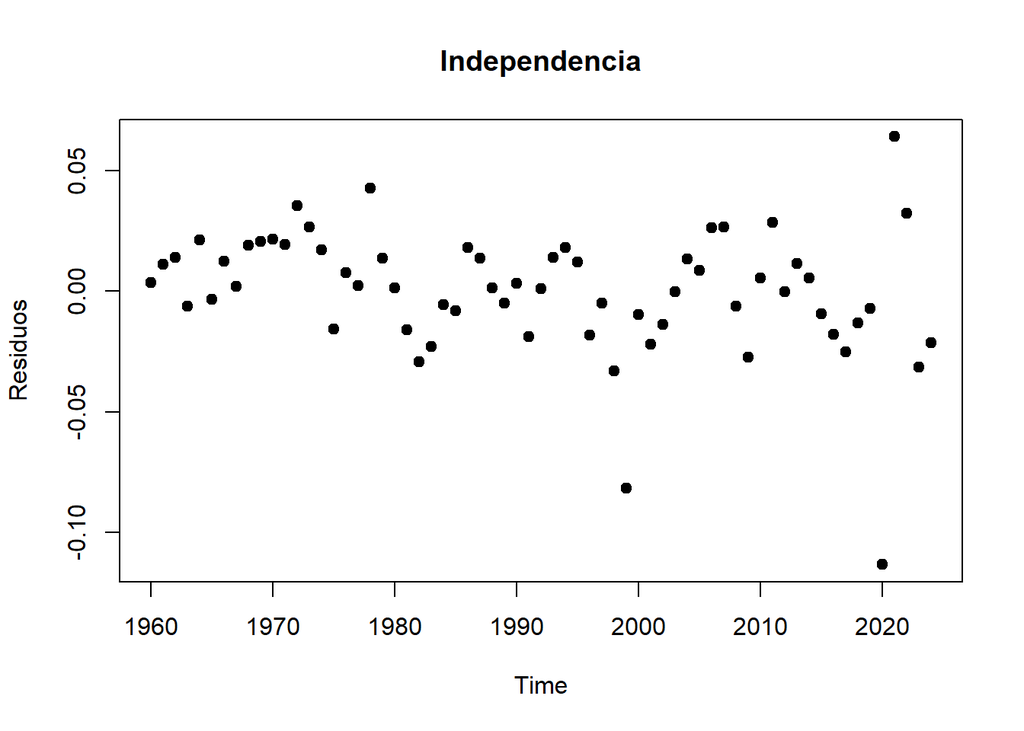

```r
plot(resid, type = "p", pch = 21, bg = "black",
     main = "Independencia", xlab = "Time", ylab = "Residuos")
```

```r
resid= arima_auto$residuals

Box.test(resid, lag = 10, type = "Ljung-Box")
```

```
##
##  Box-Ljung test
##
## data:  resid
## X-squared = 4.7241, df = 10, p-value = 0.9088
```

Observamos en la gráfica que los residuos se comportan de manera independiente además el p-value de la prueba Box-Ljung es mayor al 5%, por lo cual no hay evidencia suficiente para rechazar la hipótesis nula, es decir, existe independencia en los residuos.

### Normalidad de los residuos

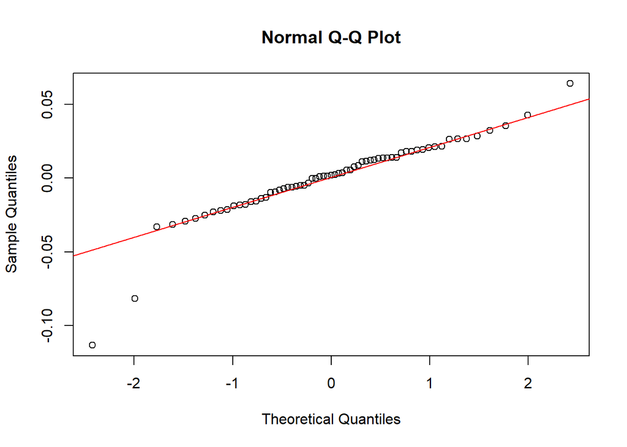

```r
qqnorm(resid)
qqline(resid, col= "red")
```

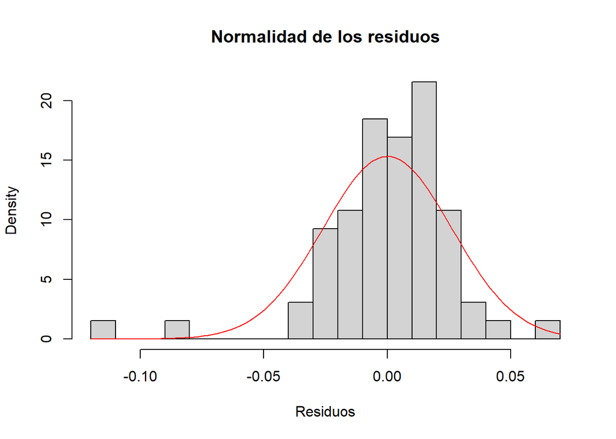

```r
hist(resid, breaks = 15, main = "Normalidad de los residuos", xlab =
       "Residuos", prob = TRUE)
curve(dnorm(x, mean = mean(resid), sd = sd(resid))
      , add = TRUE, col = "red")
```

Observamos que los residuos no sigen de la mejor manera una distribución normal, debido a que hay datos atípicos presentados en los extremos, sin embargo, para verificar la normalidad de los residuos nos apoyamos en el test de Shapiro y Jarque Bera.

```r
shapiro.test(resid)
```

```
##
##  Shapiro-Wilk normality test
##
## data:  resid
## W = 0.89192, p-value = 3.54e-05
```

```r
jarque.bera.test(resid)
```

```
##
##  Jarque Bera Test
##
## data:  resid
## X-squared = 98.269, df = 2, p-value < 2.2e-16
```

Observamos que ambos test tienen un p-value menor al 5% es decir, hay evidencia suficiente para rechazar la hipótesis nula a favor de la alterna, en consecuencia los residuos no siguen una distribución normal.

### Supuesto homocedasticidad

Graficamos los residuos para observar su comportamiento y nos apoyamos en la función  
ArchTest para verificar la existencia de homocedasticidad.

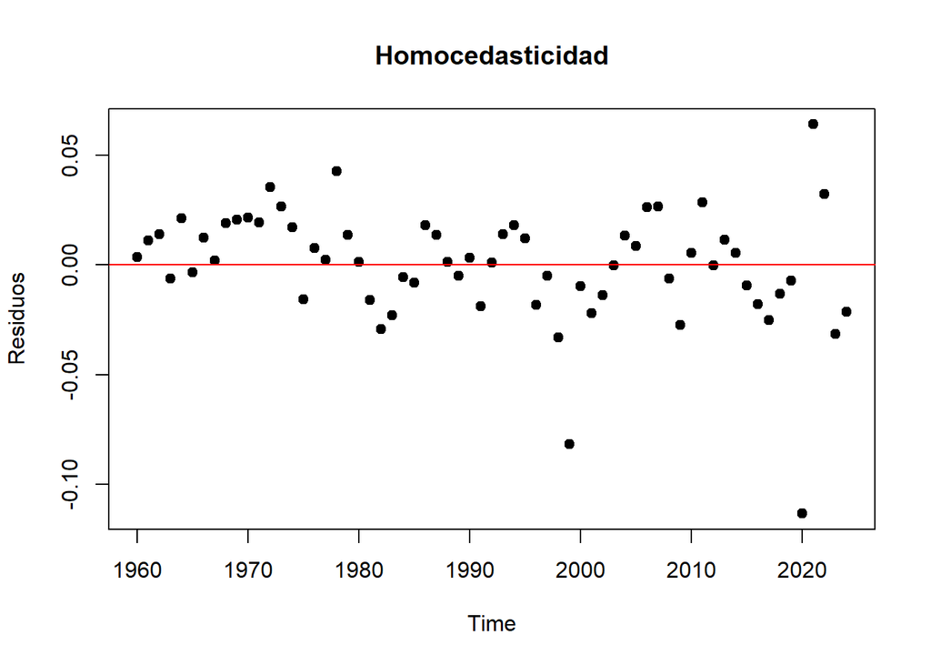

```r
plot(resid, type="b" , lty="blank", pch=21, bg="black" , main="Homocedasticidad", xlab="Time", ylab="Residuos")
abline(h = 0, col = "red")
```

```r
ArchTest(resid)
```

```
##
##  ARCH LM-test; Null hypothesis: no ARCH effects
##
## data:  resid
## Chi-squared = 3.3592, df = 12, p-value = 0.9924
```

Observamos en la gráfica que los residuos son constantes, por otro lado el p-value de la prueba Arch es mayor a 5% por ende, no hay evidencia suficiente para rechazar el hipótesis nula, es decir hay homocedasticidad.

## **Pronóstico**

Habiendo realizado todos supuestos, para el año 2025, 2026 y 2027.

```r
pronostico= forecast(arima_auto, h=3)
summary(pronostico)
```

```
##
## Forecast method: ARIMA(0,1,0) with drift
##
## Model Information:
## Series: PIB
## ARIMA(0,1,0) with drift
##
## Coefficients:
##        drift
##       0.0387
## s.e.  0.0033
##
## sigma^2 = 0.0006895:  log likelihood = 142.65
## AIC=-281.29   AICc=-281.09   BIC=-276.97
##
## Error measures:
##                        ME       RMSE        MAE        MPE     MAPE      MASE
## Training set 5.203959e-05 0.02585119 0.01817017 0.02391035 0.374892 0.4291728
##                   ACF1
## Training set 0.1563144
##
## Forecasts:
##      Point Forecast    Lo 80    Hi 80    Lo 95    Hi 95
## 2025       5.934473 5.900821 5.968124 5.883008 5.985938
## 2026       5.973138 5.925548 6.020728 5.900355 6.045921
## 2027       6.011803 5.953517 6.070089 5.922662 6.100944
```

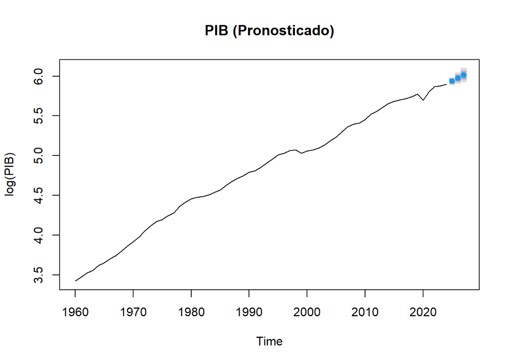

| ano | Pronostico | confianza_Lo95 | confianza_Hi95 |
| --- | --- | --- | --- |
| 2025 | 377.8408 | 358.8872 | 397.7955 |
| 2026 | 392.7361 | 365.1671 | 422.3866 |
| 2027 | 408.2187 | 373.4044 | 446.2789 |

```r
plot(pronostico, type="l", lty="solid", col="black", main= "PIB (Pronosticado)",
     xlab = "Time", ylab = "log(PIB)" )
```

## **Resumen**

Para el 2025 el pronóstico del PIB es de 377,8 mil millones de dólares, es decir, un incremento del PIB de 3.93% respecto al 2024. Dentro del intervalo de confianza al 95% el PIB se econtrará entre 358.8 y 397.7 mil millones de dólares.

Para el 2026 el pronóstico del PIB es de 392.7 mil millones de dólares, es decir, un crecimiento del 3.94% respecto al 2025. Dentro del intervalo de confianza al 95% el PIB se econtrará entre 365.1 y 422.3 mil millones de dólares.

## **Conclusión**

El presente ejercicio tuvo como objetivo la aplicación de un modelo ARIMA al análisis del Producto Interno Bruto (PIB) de Colombia durante el periodo comprendido entre 1960 y 2024. El modelo estimado, de estructura ARIMA(0,1,0), mostró un comportamiento de tipo ruido blanco, lo que indica la ausencia de una estructura autoregresiva o de medias móviles significativa en la serie una vez diferenciada. Este resultado refleja que las variaciones del PIB en el tiempo no siguen un patrón predecible mediante un modelo univariado simple.

A pesar de su simplicidad, este ejercicio permitió comprender la facilidad y utilidad de los modelos ARIMA dentro del enfoque propuesto por la metodología de Box y Jenkins, la cual proporciona un marco sistemático para la identificación, estimación y validación de modelos de series de tiempo. Sin embargo, también evidencia las limitaciones de este tipo de modelos cuando se aplican de manera aislada, ya que no consideran otros factores económicos relevantes que pueden influir en el comportamiento del PIB, como la inflación, los aranceles, el gasto público o las tasas de interés.

Por tanto, se resalta la importancia de complementar los modelos ARIMA con enfoques multivariables, como los modelos VAR o los modelos estructurales, que permiten incorporar múltiples variables explicativas y captar de forma más precisa las interrelaciones económicas que afectan el crecimiento del PIB.